# 高雄房地產_預測範例

CCW

2023-10-10

## 互動式地圖視覺化與模型預測之探討–高雄房地產價格資訊系統之評價與實作

> **第三部分：房價模型分析及預測**

> 一、房價模型之建立

> 首先將初級資料匯入R的工作區，當中有 22個變數，資料取至臺灣經濟新報(TEJ)數據庫之不動產實價登錄系統，期間範圍為兩年(2019年7月1日至2021年6月30日)，資料筆數為30863筆，其資料結構如下R碼所示。

```r
df <- read.csv("./高雄房地產_預測範例.csv")
str(df)
```

```
## 'data.frame':    30863 obs. of  22 variables:
##  $ 鄉鎮市區        : chr  "楠梓區" "三民區" "小港區" "新興區" ...
##  $ 交易標的        : chr  "房地(土地+建物)+車位" "房地(土地+建物)" "房地(土地+建物)" "房地(土地+建物)+車位" ...
##  $ 臨路.Y.N.       : chr  "Y" "N" "Y" "Y" ...
##  $ 土地            : int  1 1 1 1 1 1 2 1 1 1 ...
##  $ 建物            : int  1 1 1 1 1 1 1 1 1 1 ...
##  $ 車位            : int  1 0 0 1 0 0 0 0 0 1 ...
##  $ 土地移轉坪數    : num  5.66 2.18 40.3 5.65 38.8 ...
##  $ 都市土地使用分區: chr  "住宅區" "商業區" "住宅區" "商業區" ...
##  $ 移轉樓層        : chr  "十五層" "六層" "全" "九層" ...
##  $ 總樓層          : int  15 18 3 15 4 4 12 14 4 15 ...
##  $ 頂樓註記.Y.N.   : chr  "Y" "N" "N" "N" ...
##  $ 建物型態        : chr  "住宅大樓(11層含以上有電梯)" "住宅大樓(11層含以上有電梯)" "透天厝" "住宅大樓(11層含以上有電梯)" ...
##  $ 屋齡.年.        : num  3.7 26.1 0.9 9.6 6 0.2 25 0.8 31.5 2.2 ...
##  $ 建物移轉坪數    : num  56.4 24.3 64.2 84.2 80.2 ...
##  $ 格局.房數       : int  3 2 5 4 5 4 3 2 4 3 ...
##  $ 格局.廳數       : int  2 2 2 2 2 2 2 2 2 2 ...
##  $ 格局.衛浴數     : int  2 2 5 2 6 3 2 1 3 2 ...
##  $ 管理組織.Y.N.   : chr  "Y" "Y" "N" "Y" ...
##  $ 車位總面積.坪.  : num  5.39 0 0 7.16 0 0 0 0 0 3.99 ...
##  $ 總價.萬.        : int  1080 356 1350 1860 2280 1560 500 687 850 2092 ...
##  $ 單價.萬.坪.     : num  18.5 14.7 21 22.1 28.4 24.6 10.5 22.5 15.4 29.1 ...
##  $ 車位總價.萬.    : int  138 0 0 0 0 0 0 0 0 0 ...
```

> 根據上述的資料結構，變更部分變數的屬性，將屬性為**chr**轉換為**Factor**。

```r
library(tidyverse)
df <- df %>% mutate_if(is.character,as.factor)
str(df)
```

```
## 'data.frame':    30863 obs. of  22 variables:
##  $ 鄉鎮市區        : Factor w/ 30 levels "三民區","大社區",..: 21 1 5 20 6 13 13 7 5 12 ...
##  $ 交易標的        : Factor w/ 2 levels "房地(土地+建物)",..: 2 1 1 2 1 1 1 1 1 2 ...
##  $ 臨路.Y.N.       : Factor w/ 2 levels "N","Y": 2 1 2 2 2 1 1 2 2 2 ...
##  $ 土地            : int  1 1 1 1 1 1 2 1 1 1 ...
##  $ 建物            : int  1 1 1 1 1 1 1 1 1 1 ...
##  $ 車位            : int  1 0 0 1 0 0 0 0 0 1 ...
##  $ 土地移轉坪數    : num  5.66 2.18 40.3 5.65 38.8 ...
##  $ 都市土地使用分區: Factor w/ 7 levels "工業區","住宅區",..: 2 6 2 6 2 2 2 2 2 6 ...
##  $ 移轉樓層        : Factor w/ 218 levels "一層","一層，二層",..: 154 199 212 82 212 212 117 117 212 82 ...
##  $ 總樓層          : int  15 18 3 15 4 4 12 14 4 15 ...
##  $ 頂樓註記.Y.N.   : Factor w/ 2 levels "N","Y": 2 1 1 1 1 1 1 1 1 1 ...
##  $ 建物型態        : Factor w/ 11 levels "工廠","公寓(5樓含以下無電梯)",..: 3 3 7 3 7 7 3 3 7 3 ...
##  $ 屋齡.年.        : num  3.7 26.1 0.9 9.6 6 0.2 25 0.8 31.5 2.2 ...
##  $ 建物移轉坪數    : num  56.4 24.3 64.2 84.2 80.2 ...
##  $ 格局.房數       : int  3 2 5 4 5 4 3 2 4 3 ...
##  $ 格局.廳數       : int  2 2 2 2 2 2 2 2 2 2 ...
##  $ 格局.衛浴數     : int  2 2 5 2 6 3 2 1 3 2 ...
##  $ 管理組織.Y.N.   : Factor w/ 2 levels "N","Y": 2 2 1 2 1 1 2 2 1 2 ...
##  $ 車位總面積.坪.  : num  5.39 0 0 7.16 0 0 0 0 0 3.99 ...
##  $ 總價.萬.        : int  1080 356 1350 1860 2280 1560 500 687 850 2092 ...
##  $ 單價.萬.坪.     : num  18.5 14.7 21 22.1 28.4 24.6 10.5 22.5 15.4 29.1 ...
##  $ 車位總價.萬.    : int  138 0 0 0 0 0 0 0 0 0 ...
```

> 接著，查看資料檔內的建物型態有多少類型，並分別計算其相對應的筆數。

```r
levels(df$建物型態)
```

```
##  [1] "工廠"                       "公寓(5樓含以下無電梯)"
##  [3] "住宅大樓(11層含以上有電梯)" "其他"
##  [5] "店面(店鋪)"                 "套房(1房1廳1衛)"
##  [7] "透天厝"                     "華廈(10層含以下有電梯)"
##  [9] "農舍"                       "廠辦"
## [11] "辦公商業大樓"
```

```r
df %>% group_by(建物型態) %>% summarise(筆數=n())
```

```
## # A tibble: 11 × 2
##    建物型態                    筆數
##    <fct>                      <int>
##  1 工廠                          44
##  2 公寓(5樓含以下無電梯)       1370
##  3 住宅大樓(11層含以上有電梯) 19795
##  4 其他                          10
##  5 店面(店鋪)                   156
##  6 套房(1房1廳1衛)              481
##  7 透天厝                      6514
##  8 華廈(10層含以下有電梯)      2370
##  9 農舍                           4
## 10 廠辦                          40
## 11 辦公商業大樓                  79
```

> 將資料檔**「建物型態」**之類別水準，分別建立其所屬資料子集。因**「住宅大樓(11層含以上有電梯)」**的筆數最多，所以後續將以該類建物示範其房價要如何預測。其餘不同類型建物的房價，都可按照以下的範例程序來預測。

```r
df_住宅大樓 <- filter(df, df$建物型態=="住宅大樓(11層含以上有電梯)")
df_透天厝 <- filter(df, df$建物型態=="透天厝")  #6514 obs.
df_華廈 <- filter(df, df$建物型態=="華廈(10層含以下有電梯)")
df_公寓 <- filter(df, df$建物型態=="公寓(5樓含以下無電梯)")
df_套房 <- filter(df, df$建物型態=="套房(1房1廳1衛)")
df_店面 <- filter(df, df$建物型態=="店面(店鋪)")
df_工廠 <- filter(df, df$建物型態=="工廠")
df_廠辦 <- filter(df, df$建物型態=="廠辦")
df_其他 <- filter(df, df$建物型態=="其他")
```

> 檢視資料子集「df_住宅大樓」的變數個數與結構，並繼續必要的資料清理，以建立適切的資料子集，供後續的資料分析與預測模型之建立用。

```r
str(df_住宅大樓)
```

```
## 'data.frame':    19795 obs. of  22 variables:
##  $ 鄉鎮市區        : Factor w/ 30 levels "三民區","大社區",..: 21 1 20 13 7 12 23 26 26 26 ...
##  $ 交易標的        : Factor w/ 2 levels "房地(土地+建物)",..: 2 1 2 1 1 2 1 2 1 1 ...
##  $ 臨路.Y.N.       : Factor w/ 2 levels "N","Y": 2 1 2 1 2 2 2 2 2 2 ...
##  $ 土地            : int  1 1 1 2 1 1 1 1 1 1 ...
##  $ 建物            : int  1 1 1 1 1 1 1 1 1 1 ...
##  $ 車位            : int  1 0 1 0 0 1 0 1 0 0 ...
##  $ 土地移轉坪數    : num  5.66 2.18 5.65 10.46 3.23 ...
##  $ 都市土地使用分區: Factor w/ 7 levels "工業區","住宅區",..: 2 6 6 2 2 6 6 2 2 2 ...
##  $ 移轉樓層        : Factor w/ 218 levels "一層","一層，二層",..: 154 199 82 117 117 82 194 121 205 188 ...
##  $ 總樓層          : int  15 18 15 12 14 15 15 12 23 14 ...
##  $ 頂樓註記.Y.N.   : Factor w/ 2 levels "N","Y": 2 1 1 1 1 1 1 1 1 1 ...
##  $ 建物型態        : Factor w/ 11 levels "工廠","公寓(5樓含以下無電梯)",..: 3 3 3 3 3 3 3 3 3 3 ...
##  $ 屋齡.年.        : num  3.7 26.1 9.6 25 0.8 2.2 13.9 23.8 24.9 22.1 ...
##  $ 建物移轉坪數    : num  56.4 24.3 84.2 47.8 30.6 ...
##  $ 格局.房數       : int  3 2 4 3 2 3 2 1 3 2 ...
##  $ 格局.廳數       : int  2 2 2 2 2 2 1 2 2 1 ...
##  $ 格局.衛浴數     : int  2 2 2 2 1 2 1 1 2 1 ...
##  $ 管理組織.Y.N.   : Factor w/ 2 levels "N","Y": 2 2 2 2 2 2 2 2 2 2 ...
##  $ 車位總面積.坪.  : num  5.39 0 7.16 0 0 3.99 0 0 0 0 ...
##  $ 總價.萬.        : int  1080 356 1860 500 687 2092 550 256 540 280 ...
##  $ 單價.萬.坪.     : num  18.5 14.7 22.1 10.5 22.5 29.1 21.5 11.3 12.8 11.8 ...
##  $ 車位總價.萬.    : int  138 0 0 0 0 0 0 0 0 0 ...
```

> 因資料子集「df_住宅大樓」即為住宅大樓而設，所以刪除**「建物型態」**該欄位。另外，該資料子集的**「移轉樓層」**類別有218種之多，所以刪除**「移轉樓層」**該欄位，以利往後預測模型的建立。 此時資料子集「df_住宅大樓」的所有**20**個變數均與住宅大樓有關，與其它諸如透天、公寓等**「建物型態」**無關。至此，我們已初步完成資料子集「df_住宅大樓」資料清理的程序。簡單R碼如下：。

```r
df_住宅大樓 <- select(df_住宅大樓, -c(建物型態, 移轉樓層))
str(df_住宅大樓)
```

```
## 'data.frame':    19795 obs. of  20 variables:
##  $ 鄉鎮市區        : Factor w/ 30 levels "三民區","大社區",..: 21 1 20 13 7 12 23 26 26 26 ...
##  $ 交易標的        : Factor w/ 2 levels "房地(土地+建物)",..: 2 1 2 1 1 2 1 2 1 1 ...
##  $ 臨路.Y.N.       : Factor w/ 2 levels "N","Y": 2 1 2 1 2 2 2 2 2 2 ...
##  $ 土地            : int  1 1 1 2 1 1 1 1 1 1 ...
##  $ 建物            : int  1 1 1 1 1 1 1 1 1 1 ...
##  $ 車位            : int  1 0 1 0 0 1 0 1 0 0 ...
##  $ 土地移轉坪數    : num  5.66 2.18 5.65 10.46 3.23 ...
##  $ 都市土地使用分區: Factor w/ 7 levels "工業區","住宅區",..: 2 6 6 2 2 6 6 2 2 2 ...
##  $ 總樓層          : int  15 18 15 12 14 15 15 12 23 14 ...
##  $ 頂樓註記.Y.N.   : Factor w/ 2 levels "N","Y": 2 1 1 1 1 1 1 1 1 1 ...
##  $ 屋齡.年.        : num  3.7 26.1 9.6 25 0.8 2.2 13.9 23.8 24.9 22.1 ...
##  $ 建物移轉坪數    : num  56.4 24.3 84.2 47.8 30.6 ...
##  $ 格局.房數       : int  3 2 4 3 2 3 2 1 3 2 ...
##  $ 格局.廳數       : int  2 2 2 2 2 2 1 2 2 1 ...
##  $ 格局.衛浴數     : int  2 2 2 2 1 2 1 1 2 1 ...
##  $ 管理組織.Y.N.   : Factor w/ 2 levels "N","Y": 2 2 2 2 2 2 2 2 2 2 ...
##  $ 車位總面積.坪.  : num  5.39 0 7.16 0 0 3.99 0 0 0 0 ...
##  $ 總價.萬.        : int  1080 356 1860 500 687 2092 550 256 540 280 ...
##  $ 單價.萬.坪.     : num  18.5 14.7 22.1 10.5 22.5 29.1 21.5 11.3 12.8 11.8 ...
##  $ 車位總價.萬.    : int  138 0 0 0 0 0 0 0 0 0 ...
```

> 為求變數間的相關，需再剔除些無關模型建立的變數，此時我們還需將資料子集「df_住宅大樓」的變數分類為兩群，第1群為量化變數(quantitative variables)，共有**7**個;

```r
library(ClustOfVar)
quantity <- df_住宅大樓[,c("土地移轉坪數","總樓層","屋齡.年.","建物移轉坪數","車位總面積.坪.","單價.萬.坪.","車位總價.萬.")]
str(quantity)
```

```
## 'data.frame':    19795 obs. of  7 variables:
##  $ 土地移轉坪數  : num  5.66 2.18 5.65 10.46 3.23 ...
##  $ 總樓層        : int  15 18 15 12 14 15 15 12 23 14 ...
##  $ 屋齡.年.      : num  3.7 26.1 9.6 25 0.8 2.2 13.9 23.8 24.9 22.1 ...
##  $ 建物移轉坪數  : num  56.4 24.3 84.2 47.8 30.6 ...
##  $ 車位總面積.坪.: num  5.39 0 7.16 0 0 3.99 0 0 0 0 ...
##  $ 單價.萬.坪.   : num  18.5 14.7 22.1 10.5 22.5 29.1 21.5 11.3 12.8 11.8 ...
##  $ 車位總價.萬.  : int  138 0 0 0 0 0 0 0 0 0 ...
```

> 第2群為質性變數(qualitative variables)，共有**6**個。

```r
quality <- df_住宅大樓[,c("鄉鎮市區","交易標的","臨路.Y.N.","都市土地使用分區","頂樓註記.Y.N.","管理組織.Y.N.")]
str(quality)
```

```
## 'data.frame':    19795 obs. of  6 variables:
##  $ 鄉鎮市區        : Factor w/ 30 levels "三民區","大社區",..: 21 1 20 13 7 12 23 26 26 26 ...
##  $ 交易標的        : Factor w/ 2 levels "房地(土地+建物)",..: 2 1 2 1 1 2 1 2 1 1 ...
##  $ 臨路.Y.N.       : Factor w/ 2 levels "N","Y": 2 1 2 1 2 2 2 2 2 2 ...
##  $ 都市土地使用分區: Factor w/ 7 levels "工業區","住宅區",..: 2 6 6 2 2 6 6 2 2 2 ...
##  $ 頂樓註記.Y.N.   : Factor w/ 2 levels "N","Y": 2 1 1 1 1 1 1 1 1 1 ...
##  $ 管理組織.Y.N.   : Factor w/ 2 levels "N","Y": 2 2 2 2 2 2 2 2 2 2 ...
```

> 不論變數是量化或質性，我們可利用R套件{ClustOfVar}函數 *hclustvar()* 所提供的變數樹狀圖(variables dendrogram)，觀察資料子集「df_住宅大樓」變數間的相關性，以利後續預測迴歸的變數選取。另外，我們可以檢視產生變數集群需時多少。

```r
ptm <- proc.time()
tree <- hclustvar(quantity,quality)
proc.time()-ptm
```

```
##    user  system elapsed
##    6.30    0.45    6.78
```

> 將變數集群後，產生變數樹狀圖，以利我們觀察變數間的相關程度。

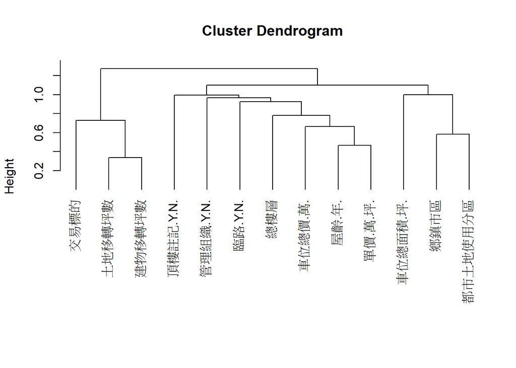

```r
plot(tree)
```

> 獲得變數相關樹狀圖之後，可分別將變數集合成2、3、4、5群不等的群變數(clustered variables)，要將資料變數分幾群，由使用者的背景知識來做主觀決定。 若分成2群，其群變數的成分包括有:

```r
P2<-cutreevar(tree,2)
P2$var
```

```
## $cluster1
##              squared loading correlation
## 建物移轉坪數       0.7878057  -0.8875842
## 土地移轉坪數       0.7106390  -0.8429941
## 交易標的           0.4353154          NA
##
## $cluster2
##                  squared loading  correlation
## 單價.萬.坪.         7.050052e-01  0.839645850
## 車位總價.萬.        4.156168e-01  0.644683487
## 屋齡.年.            4.005856e-01 -0.632918344
## 鄉鎮市區            3.828669e-01           NA
## 總樓層              3.042026e-01  0.551545676
## 臨路.Y.N.           1.288651e-01           NA
## 都市土地使用分區    1.284778e-01           NA
## 管理組織.Y.N.       4.974145e-02           NA
## 頂樓註記.Y.N.       4.739319e-03           NA
## 車位總面積.坪.      3.142907e-05 -0.005606163
```

> 若分成3群，其群變數的成分包括有:

```r
P3<-cutreevar(tree,3)
P3$var
```

```
## $cluster1
##              squared loading correlation
## 建物移轉坪數       0.7878057  -0.8875842
## 土地移轉坪數       0.7106390  -0.8429941
## 交易標的           0.4353154          NA
##
## $cluster2
##               squared loading correlation
## 單價.萬.坪.       0.694541666   0.8333917
## 屋齡.年.          0.535507327  -0.7317837
## 車位總價.萬.      0.468582822   0.6845311
## 總樓層            0.312628031   0.5591315
## 臨路.Y.N.         0.128418912          NA
## 管理組織.Y.N.     0.056199328          NA
## 頂樓註記.Y.N.     0.005766676          NA
##
## $cluster3
##                  squared loading correlation
## 鄉鎮市區            0.7084760633          NA
## 都市土地使用分區    0.7083003053          NA
## 車位總面積.坪.      0.0008221703  0.02867351
```

> 若分成4群，其群變數的成分包括有:

```r
P4<-cutreevar(tree,4)
P4$var
```

```
## $cluster1
##              squared loading correlation
## 建物移轉坪數       0.7878057  -0.8875842
## 土地移轉坪數       0.7106390  -0.8429941
## 交易標的           0.4353154          NA
##
## $cluster2
##               squared loading correlation
## 單價.萬.坪.       0.694541666   0.8333917
## 屋齡.年.          0.535507327  -0.7317837
## 車位總價.萬.      0.468582822   0.6845311
## 總樓層            0.312628031   0.5591315
## 臨路.Y.N.         0.128418912          NA
## 管理組織.Y.N.     0.056199328          NA
## 頂樓註記.Y.N.     0.005766676          NA
##
## $cluster3
## squared loading     correlation
##               1               1
##
## $cluster4
##                  squared loading correlation
## 都市土地使用分區       0.7086789          NA
## 鄉鎮市區               0.7086789          NA
```

> 若分成5群，其群變數的成分包括有

```r
P5<-cutreevar(tree,5)
P5$var
```

```
## $cluster1
##              squared loading correlation
## 建物移轉坪數       0.7878057  -0.8875842
## 土地移轉坪數       0.7106390  -0.8429941
## 交易標的           0.4353154          NA
##
## $cluster2
##               squared loading correlation
## 單價.萬.坪.        0.69580340   0.8341483
## 屋齡.年.           0.53725881  -0.7329794
## 車位總價.萬.       0.47009553   0.6856351
## 總樓層             0.30987816   0.5566670
## 臨路.Y.N.          0.12911931          NA
## 管理組織.Y.N.      0.05633978          NA
##
## $cluster3
## squared loading     correlation
##               1               1
##
## $cluster4
##                  squared loading correlation
## 都市土地使用分區       0.7086789          NA
## 鄉鎮市區               0.7086789          NA
##
## $cluster5
## squared loading     correlation
##               1              NA
```

> 我們可將這些集群變數視為原變數的合成(synthesis)，所以集群變數有時被稱之為合成變數(synthesized variables)，因集群變數實為原變數的線性組合(linear combination)。

```r
X.quanti <- df_住宅大樓[,c("屋齡.年.","單價.萬.坪.","車位總價.萬.")]
str(X.quanti)
```

```
## 'data.frame':    19795 obs. of  3 variables:
##  $ 屋齡.年.    : num  3.7 26.1 9.6 25 0.8 2.2 13.9 23.8 24.9 22.1 ...
##  $ 單價.萬.坪. : num  18.5 14.7 22.1 10.5 22.5 29.1 21.5 11.3 12.8 11.8 ...
##  $ 車位總價.萬.: int  138 0 0 0 0 0 0 0 0 0 ...
```

```r
X.quali <- df_住宅大樓[,c("鄉鎮市區","臨路.Y.N.","都市土地使用分區","管理組織.Y.N.")]
str(X.quali)
```

```
## 'data.frame':    19795 obs. of  4 variables:
##  $ 鄉鎮市區        : Factor w/ 30 levels "三民區","大社區",..: 21 1 20 13 7 12 23 26 26 26 ...
##  $ 臨路.Y.N.       : Factor w/ 2 levels "N","Y": 2 1 2 1 2 2 2 2 2 2 ...
##  $ 都市土地使用分區: Factor w/ 7 levels "工業區","住宅區",..: 2 6 6 2 2 6 6 2 2 2 ...
##  $ 管理組織.Y.N.   : Factor w/ 2 levels "N","Y": 2 2 2 2 2 2 2 2 2 2 ...
```

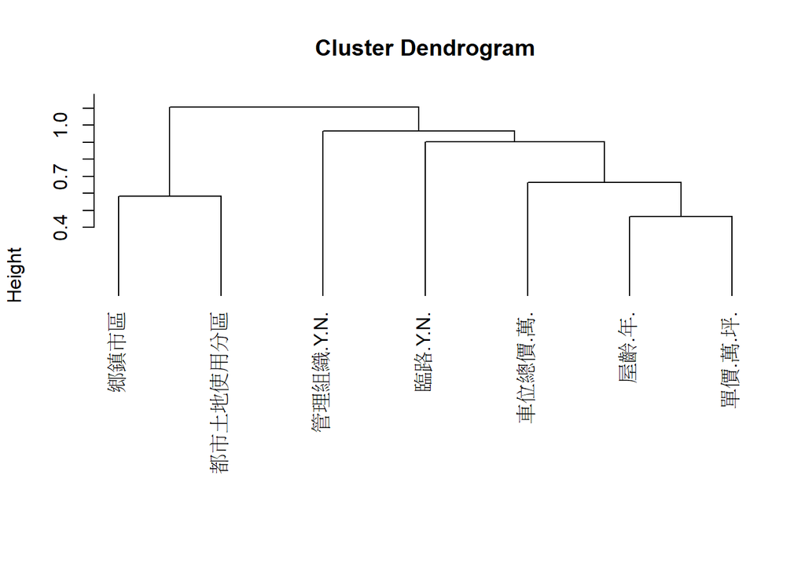

```r
treeX <- hclustvar(X.quanti,X.quali)
plot(treeX)
```

> 由上述的變數相關樹狀圖(dendrogram)可知，在這7個變數當中，建物(大樓住宅)的”單價.萬.坪.”與”屋齡.年.”和”車位總價.萬.”的相關最高，與”臨路.Y.N.”和”管理組織.Y.N.”的相關次之，與”鄉鎮市區”和”都市土地使用分區”的相關最低。

> 為求變數名能清晰易讀，我們將修正這7個質性與量化變數的變數名稱，R碼如下：

```r
df <- data.frame(cbind(X.quanti,X.quali))
str(df)
```

```
## 'data.frame':    19795 obs. of  7 variables:
##  $ 屋齡.年.        : num  3.7 26.1 9.6 25 0.8 2.2 13.9 23.8 24.9 22.1 ...
##  $ 單價.萬.坪.     : num  18.5 14.7 22.1 10.5 22.5 29.1 21.5 11.3 12.8 11.8 ...
##  $ 車位總價.萬.    : int  138 0 0 0 0 0 0 0 0 0 ...
##  $ 鄉鎮市區        : Factor w/ 30 levels "三民區","大社區",..: 21 1 20 13 7 12 23 26 26 26 ...
##  $ 臨路.Y.N.       : Factor w/ 2 levels "N","Y": 2 1 2 1 2 2 2 2 2 2 ...
##  $ 都市土地使用分區: Factor w/ 7 levels "工業區","住宅區",..: 2 6 6 2 2 6 6 2 2 2 ...
##  $ 管理組織.Y.N.   : Factor w/ 2 levels "N","Y": 2 2 2 2 2 2 2 2 2 2 ...
```

```r
colnames(df) <- c("屋齡","單價","車位總價","鄉鎮市區","臨路","都市土地使用分區","管理組織")
str(df)
```

```
## 'data.frame':    19795 obs. of  7 variables:
##  $ 屋齡            : num  3.7 26.1 9.6 25 0.8 2.2 13.9 23.8 24.9 22.1 ...
##  $ 單價            : num  18.5 14.7 22.1 10.5 22.5 29.1 21.5 11.3 12.8 11.8 ...
##  $ 車位總價        : int  138 0 0 0 0 0 0 0 0 0 ...
##  $ 鄉鎮市區        : Factor w/ 30 levels "三民區","大社區",..: 21 1 20 13 7 12 23 26 26 26 ...
##  $ 臨路            : Factor w/ 2 levels "N","Y": 2 1 2 1 2 2 2 2 2 2 ...
##  $ 都市土地使用分區: Factor w/ 7 levels "工業區","住宅區",..: 2 6 6 2 2 6 6 2 2 2 ...
##  $ 管理組織        : Factor w/ 2 levels "N","Y": 2 2 2 2 2 2 2 2 2 2 ...
```

> 接著就用這「單價」、「屋齡」、「車位總價」、「鄉鎮市區」、「臨路」、「都市土地使用分區」、「管理組織」等7個變數，來建立迴歸預測模型。

> 但在建立迴歸預測模型前，我們需先選定一組測試每坪單價的迴歸方程所需的資料檔，用以檢視該每坪單價迴歸方程的預測能力。假設該測試資料共12筆，顯示如下:

```r
n <- sample(1:length(df$單價),12)
(test <- df[n,])
```

```
##       屋齡 單價 車位總價 鄉鎮市區 臨路 都市土地使用分區 管理組織
## 9652   1.6 28.4      570   鼓山區    Y             其他        Y
## 8670   0.6 22.2      190   苓雅區    Y             其他        Y
## 7688   7.6 40.7        0   前金區    Y           商業區        Y
## 13105 23.5 10.8        0   苓雅區    N       特定專用區        Y
## 16652 18.7 20.9        0   前金區    Y           商業區        Y
## 11019 15.1 26.8        0   鼓山區    Y       其他使用區        Y
## 13940 16.4 20.5      120   鼓山區    Y       其他使用區        Y
## 557    1.0 15.8      135   仁武區    Y           商業區        Y
## 19696  5.9 19.4        0   楠梓區    Y           住宅區        Y
## 9691  21.2 14.3        0   三民區    Y             其他        Y
## 10367 17.5 17.0        0   左營區    Y             其他        Y
## 11106  8.5 21.2        0   苓雅區    N             其他        Y
```

> 選定12筆測試用資料後，即可建立每坪單價的迴歸方程模型，其簡單的R碼如下：

```r
price <- lm(單價~., data=df[-n,])
summary(price)
```

```
##
## Call:
## lm(formula = 單價 ~ ., data = df[-n, ])
##
## Residuals:
##     Min      1Q  Median      3Q     Max
## -29.989  -2.193  -0.405   1.708  91.684
##
## Coefficients:
##                              Estimate Std. Error t value Pr(>|t|)
## (Intercept)                 2.176e+01  1.463e+00  14.870  < 2e-16 ***
## 屋齡                       -3.361e-01  3.391e-03 -99.111  < 2e-16 ***
## 車位總價                    1.355e-02  3.126e-04  43.341  < 2e-16 ***
## 鄉鎮市區大社區             -4.345e+00  5.991e-01  -7.253 4.23e-13 ***
## 鄉鎮市區大寮區             -6.181e+00  3.074e-01 -20.109  < 2e-16 ***
## 鄉鎮市區大樹區             -7.117e+00  7.799e-01  -9.125  < 2e-16 ***
## 鄉鎮市區小港區             -5.102e+00  2.092e-01 -24.386  < 2e-16 ***
## 鄉鎮市區仁武區             -6.488e+00  1.902e-01 -34.111  < 2e-16 ***
## 鄉鎮市區左營區              1.186e+00  1.025e-01  11.565  < 2e-16 ***
## 鄉鎮市區甲仙區             -1.345e+01  2.369e+00  -5.679 1.37e-08 ***
## 鄉鎮市區岡山區             -3.619e+00  2.453e-01 -14.756  < 2e-16 ***
## 鄉鎮市區林園區             -7.353e+00  6.815e-01 -10.789  < 2e-16 ***
## 鄉鎮市區阿蓮區             -4.066e+00  2.902e+00  -1.401 0.161263
## 鄉鎮市區前金區              2.639e+00  1.897e-01  13.913  < 2e-16 ***
## 鄉鎮市區前鎮區              4.984e-01  1.400e-01   3.559 0.000373 ***
## 鄉鎮市區苓雅區              1.100e+00  1.348e-01   8.161 3.51e-16 ***
## 鄉鎮市區茄萣區             -9.671e+00  7.843e-01 -12.331  < 2e-16 ***
## 鄉鎮市區鳥松區             -7.099e-01  3.552e-01  -1.999 0.045650 *
## 鄉鎮市區湖內區             -5.864e+00  7.120e-01  -8.235  < 2e-16 ***
## 鄉鎮市區新興區              1.040e+00  2.443e-01   4.258 2.07e-05 ***
## 鄉鎮市區楠梓區             -5.081e+00  1.144e-01 -44.418  < 2e-16 ***
## 鄉鎮市區路竹區             -5.157e+00  2.052e+00  -2.513 0.011971 *
## 鄉鎮市區鼓山區              2.809e+00  1.158e-01  24.267  < 2e-16 ***
## 鄉鎮市區旗山區             -6.660e+00  1.676e+00  -3.974 7.10e-05 ***
## 鄉鎮市區旗津區             -7.972e+00  4.101e+00  -1.944 0.051904 .
## 鄉鎮市區鳳山區             -2.674e+00  1.216e-01 -21.991  < 2e-16 ***
## 鄉鎮市區橋頭區             -6.585e+00  1.557e-01 -42.285  < 2e-16 ***
## 鄉鎮市區鹽埕區             -1.718e+00  3.652e-01  -4.705 2.56e-06 ***
## 臨路Y                       8.559e-01  9.235e-02   9.268  < 2e-16 ***
## 都市土地使用分區住宅區      5.173e-01  1.453e+00   0.356 0.721732
## 都市土地使用分區其他        6.357e-01  1.454e+00   0.437 0.661967
## 都市土地使用分區其他使用區  1.438e+00  1.463e+00   0.983 0.325658
## 都市土地使用分區特定專用區  7.577e-01  1.469e+00   0.516 0.605993
## 都市土地使用分區商業區      8.017e-01  1.453e+00   0.552 0.581165
## 管理組織Y                   4.180e-01  1.917e-01   2.180 0.029259 *
## ---
## Signif. codes:  0 '***' 0.001 '**' 0.01 '*' 0.05 '.' 0.1 ' ' 1
##
## Residual standard error: 4.099 on 19748 degrees of freedom
## Multiple R-squared:  0.6034, Adjusted R-squared:  0.6028
## F-statistic: 883.8 on 34 and 19748 DF,  p-value: < 2.2e-16
```

> 由上述的模型係數的顯著性可知，自變數**「都市土地使用分區」**對應變數**「單價」**並未達到顯著(p值均遠大於0.05的一般公認水準)。 上述迴歸方程模型建立後，再將之前的12筆測試資料匯入迴歸模型，以測試該模型的預測能力。

```r
原價 <- test$單價
test$單價 <- NULL
(預測 <- predict(price, test))
```

```
##     9652     8670     7688    13105    16652    11019    13940      557
## 33.65975 27.13935 23.91805 16.13583 20.18775 22.20419 23.39285 18.83775
##    19696     9691    10367    11106
## 16.48486 16.54226 18.97129 21.05476
```

```r
new <- data.frame(cbind(原價,round(預測,1)))
str(new)
```

```
## 'data.frame':    12 obs. of  2 variables:
##  $ 原價: num  28.4 22.2 40.7 10.8 20.9 26.8 20.5 15.8 19.4 14.3 ...
##  $ V2  : num  33.7 27.1 23.9 16.1 20.2 22.2 23.4 18.8 16.5 16.5 ...
```

```r
colnames(new) <- c("原價", "預測")
new$誤差 <- ((new$原價-new$預測)^2)^0.5
str(new)
```

```
## 'data.frame':    12 obs. of  3 variables:
##  $ 原價: num  28.4 22.2 40.7 10.8 20.9 26.8 20.5 15.8 19.4 14.3 ...
##  $ 預測: num  33.7 27.1 23.9 16.1 20.2 22.2 23.4 18.8 16.5 16.5 ...
##  $ 誤差: num  5.3 4.9 16.8 5.3 0.7 ...
```

```r
new$預測結果 <- with(new,ifelse(預測 > 原價, '高估', '低估'))
```

> **預測後的結果如下所示，值得注意的是這僅是一次隨機測試的結果，且預測高估與預測低估均會隨機出現，不會持續地顯現高估或低估的現象。另外要觀察的是，該估計所產生的誤差有多大。**

```r
options(width=120)
cbind(new, df_住宅大樓[n,c(1,2,7,9,11,12,18)])
```

```
##       原價 預測 誤差 預測結果 鄉鎮市區             交易標的 土地移轉坪數 總樓層 屋齡.年. 建物移轉坪數 總價.萬.
## 9652  28.4 33.7  5.3     高估   鼓山區 房地(土地+建物)+車位        10.89     29      1.6       135.93     3899
## 8670  22.2 27.1  4.9     高估   苓雅區 房地(土地+建物)+車位         4.91     15      0.6        37.39      838
## 7688  40.7 23.9 16.8     低估   前金區 房地(土地+建物)+車位         6.80     15      7.6        73.77     3000
## 13105 10.8 16.1  5.3     高估   苓雅區      房地(土地+建物)         1.77     35     23.5        41.63      450
## 16652 20.9 20.2  0.7     低估   前金區      房地(土地+建物)         2.54     22     18.7        31.12      650
## 11019 26.8 22.2  4.6     低估   鼓山區 房地(土地+建物)+車位         5.77     20     15.1        50.40     1350
## 13940 20.5 23.4  2.9     高估   鼓山區 房地(土地+建物)+車位         4.02     14     16.4        31.26      660
## 557   15.8 18.8  3.0     高估   仁武區 房地(土地+建物)+車位         6.95     15      1.0        56.99      923
## 19696 19.4 16.5  2.9     低估   楠梓區      房地(土地+建物)         4.00     15      5.9        24.71      480
## 9691  14.3 16.5  2.2     高估   三民區 房地(土地+建物)+車位         6.00     13     21.2        52.16      745
## 10367 17.0 19.0  2.0     高估   左營區      房地(土地+建物)         2.33     14     17.5        22.77      388
## 11106 21.2 21.1  0.1     低估   苓雅區 房地(土地+建物)+車位         9.39     11      8.5        65.45     1386
```

> 二、迴歸模型變數增減的預測誤差比較

> 上述迴歸模型包含單價(應變數)在內，共有7個變數，姑且稱之為「7變數迴歸模型」。若增加迴歸模型的預測變數，例如包含單價(應變數)在內共有13個變數的「13變數迴歸模型」，其預測誤差(能力)是否會因而變小(增大)呢？我們可以建立兩組迴歸模型，分別為「7變數迴歸模型」與「13變數迴歸模型」，用相同的測試資料(例如隨機抽取12筆)加以比較這兩組迴歸模型的預測誤差，以究其優劣良窳。為方便說明筆較，我們就用上述的13變數樹狀圖的變數，來建立所需的「13變數迴歸模型」。該範例所需資料檔案已事先建立，以方便直接引用比較，而兩組資料檔名如下R碼所示。我們每一輪比較均先以10次為例，其相關R碼如下：

```r
rm(list=ls(all=TRUE))
library(tidyverse)
df_7v <- read.csv("./df_住宅大樓_7v.csv")
df_7v <- df_7v %>% mutate_if(is.character,as.factor)

df_13v <- read.csv("./df_住宅大樓_13v.csv")
df_13v <- df_13v %>% mutate_if(is.character,as.factor)

##############################################
k <- 10
誤差_7變數 = rep(0, k)
誤差_13變數 = rep(0, k)
for (i in 1:k){

n <- sample(1:length(df_7v$單價),10)
(test_7v <- df_7v[n,])
(test_13v <- df_13v[n,])
price_7v <- lm(單價~., data=df_7v[-n,])
summary(price_7v)
price_13v <- lm(單價~., data=df_13v[-n,])
summary(price_13v)

#用「7變數迴歸模型」預測房價
原價_7v <- test_7v$單價
test_7v$單價 <- NULL
(預測_7v <- predict(price_7v, test_7v))
new_7v <- data.frame(cbind(原價_7v,round(預測_7v,1)))
colnames(new_7v) <- c("原價", "預測")
new_7v$誤差 <- ((new_7v$原價-new_7v$預測)^2)^0.5
new_7v$預測結果 <- with(new_7v,ifelse(預測 > 原價, '高估', '低估'))
cbind(new_7v, df_7v[n,])

#用「13變數迴歸模型」預測房價
原價_13v <- test_13v$單價
test_13v$單價 <- NULL
預測_13v <- predict(price_13v, test_13v)
new_13v <- data.frame(cbind(原價_13v,round(預測_13v,1)))
colnames(new_13v) <- c("原價", "預測")
new_13v$誤差 <- ((new_13v$原價-new_13v$預測)^2)^0.5
new_13v$預測結果 <- with(new_13v,ifelse(預測 > 原價, '高估', '低估'))
誤差_7變數[i] <- sum(new_7v[,2])
誤差_13變數[i] <- sum(new_13v[,2])
}
```

```r
cbind(誤差_7變數,誤差_13變數)
```

```
##       誤差_7變數 誤差_13變數
##  [1,]      185.1       182.7
##  [2,]      220.5       220.3
##  [3,]      198.2       202.0
##  [4,]      175.5       176.3
##  [5,]      227.8       227.0
##  [6,]      213.0       209.4
##  [7,]      216.5       222.1
##  [8,]      189.4       189.0
##  [9,]      235.7       235.8
## [10,]      176.6       180.6
```

```r
sum(誤差_7變數)
```

```
## [1] 2038.3
```

```r
sum(誤差_13變數)
```

```
## [1] 2045.2
```

```r
誤差比較 <- as.data.frame(cbind(誤差_7變數,誤差_13變數))
colnames(誤差比較) <- c("迴歸7變數","迴歸13變數")
#誤差比較
x <- apply(誤差比較, 2, sum)
ans <- ifelse(x[[1]] < x[[2]], paste("7變數比13變數的誤差小，「7變數迴歸模型」較佳"),
                               paste("13變數比7變數的誤差小，「13變數迴歸模型」較佳"))
a <- paste("用7個變數所建立的迴歸模型，其預測誤差  =",x[1])
b <- paste("用13個變數所建立的迴歸模型，其預測誤差 =",x[2])
cat(format(Sys.time(), "%a %b %d %X %Y"),a,b,ans,sep ="\n")
```

```
## 週二 十月 10 下午 12:46:47 2023
## 用7個變數所建立的迴歸模型，其預測誤差  = 2038.3
## 用13個變數所建立的迴歸模型，其預測誤差 = 2045.2
## 7變數比13變數的誤差小，「7變數迴歸模型」較佳
```

> 另外，亦可將兩組模型預測誤差比較結果存入檔案，以利日後查閱追蹤。

```r
cat(format(Sys.time(), "%a %b %d %X %Y"),a,b,ans, "================================================",
    sep ="\n", file="誤差比較結果.txt",append=TRUE)
```

> 若想將上述預測誤差比較重複n次，並將比較結果寫入檔案，以檢視「7變數迴歸模型」或「13變數迴歸模型」何者較優時，可在原R碼加上for…loop的迴圈即可，亦可參考https://github.com/ccwatnkfust/nstc的「比較7個變數與13個變數的線性預測_n次.R」程式碼。